# Bird talk analysis

## Intro

Linguistic analysis of the language of bird vocalizations.

Load libraries:

```r
library(tidyverse)
library(measurements) # for inch to cm conversion
library(tidytext) # for unnest_tokens()
library(textstem) # for lemmatization
library(lsr) # for Cramer's V effect size
library(effsize) # for Cohen's D effect size
library(ranger) # for random forests
library(wordcloud) # for word cloud
library(gridExtra) # for multi-plots
# library(quanteda) # for keyword analysis
# library(quanteda.textmodels) # for LSA
# library(lsa) # for LSA
# library(LSAfun) # for LSA visualization and interpretation
# library(mclust) # for Gaussian mixture models
```

Get all file names:

```r
filenames <- list.files(path = '../data/fieldguides/')
```

Some of the field guides have extra information, such as on abundance. We will disregard this for now and focus on the shared columns “EnglishCommon”, “LatinSpecies”, “Length”, and “Voice”.

```r
relevant_cols <- c('EnglishCommon', 'LatinSpecies', 'Length', 'Voice')
```

Loop through the file names and get the relevant columns from the files. The “Collins Garden Birds” guide has no length information. Also, the “Felix & Hisek” guide has an extra “Song” column that will be merged with the “Voice” column. This is justified because the other guides also combine call and song features in the same section. Moreover, the “Felix & Hisek” guide does not seem to be particularly consistent in separating calls and songs.

```r
birds <- c()
for (i in seq_along(filenames)) {
  this_file <- read_csv(str_c('../data/fieldguides/', filenames[i]))

  # For Felix & Hisek only, merge "Voice" and "Song" columns:

  if (filenames[i] == 'felix_hisek_birds.csv') {
    this_file[is.na(this_file$Song), ]$Song <- ''
    this_file <- mutate(this_file, Voice = str_c(Voice, ' ', Song))
  }

  # Get all relevant columns, except for Collins Gem:

  if (filenames[i] != 'collins_gem_garden_birds.csv') {
    this_file <- select(this_file, relevant_cols)
  } else {
    this_file$Length <- NA
    this_file <- select(this_file, relevant_cols)
  }

  # Append a column with info about the guide:

  this_file$FieldGuide <- rep(filenames[i], nrow(this_file))

  # Merge with main data frame that is growing:

  birds <- rbind(birds, this_file)
}
```

Clean the guide column to get rid of “.csv”:

```r
birds <- mutate(birds,
                FieldGuide = str_replace(FieldGuide, '\\.csv', ''))
```

## Summary information

How many entries altogether?

```r
nrow(birds)
```

```
## [1] 6046
```

How many per field guide?

```r
table(birds$FieldGuide)
```

```
##
##  allabout_birds_raw_processed            bruun_hamlyn_guide
##                           619                           428
##        collins_british_common          collins_british_rare
##                           248                           291
##             collins_gem_birds      collins_gem_garden_birds
##                           236                           100
##             felix_hisek_birds          holden_cleeves_birds
##                           256                           272
##               mackinnon_china            morcombe_australia
##                           178                           799
##   national_geographic_america   national_trust_bird_spotter
##                           926                           144
##        peterson_chalif_mexico                 rspb_brereton
##                           444                            91
##      rspb_pocket_birds_harrap        simpson_day_australian
##                           212                           599
## tarboton_kruger_national_park
##                           203
```

How many bird species?

```r
length(unique(birds$LatinSpecies))
```

```
## [1] 2817
```

How many per species?

```r
mean(table(birds$LatinSpecies))
```

```
## [1] 2.146255
```

Approximating 2 per species…

Look at the ones for which we have most info:

```r
birds %>% count(LatinSpecies, sort = TRUE)
```

```
## # A tibble: 2,817 x 2
##    LatinSpecies            n
##    <chr>               <int>
##  1 Hirundo rustica        14
##  2 Phasianus colchicus    14
##  3 Sturnus vulgaris       14
##  4 Tyto alba              14
##  5 Anas platyrhynchos     13
##  6 Cygnus olor            13
##  7 Fulica atra            13
##  8 Passer domesticus      13
##  9 Phalacrocorax carbo    13
## 10 Sterna hirundo         13
## # … with 2,807 more rows
```

## Process length

Get rid of the “span” information in Morcobe Australia:

```r
aus_length <- str_split(birds[birds$FieldGuide == 'morcombe_australia', ]$Length,
          pattern = '(; span)|(; includes)', simplify = TRUE)[, 1]

birds[birds$FieldGuide == 'morcombe_australia', ]$Length <- aus_length
```

Get rid of “cm”:

```r
birds <- mutate(birds,
                Length = str_replace_all(Length, 'cm', ''))
```

Replace “WS” (wingspan) with NAs for now, to not put apples and oranges together. Will have to find the actual length for these:

```r
birds[which(str_detect(birds$Length, 'WS')), ]$Length <- NA
```

Loop through and make into numeric, averaging over ranges (e.g., “38-42”) and also over male/female:

```r
lengths <- str_extract_all(birds$Length, '([0-9]+\\.5)|([0-9]+)')

birds$Length <- sapply(lengths, FUN = function(x) mean(as.numeric(x)))
```

Convert Peterson & Chalif inches to cm:

```r
mex_length <- conv_unit(birds[birds$FieldGuide == 'peterson_chalif_mexico', ]$Length,
          'inch', 'cm')

birds[birds$FieldGuide == 'peterson_chalif_mexico', ]$Length <- mex_length
```

Create a median split:

```r
birds <- mutate(birds,
                BigOrSmall = ifelse(!is.na(Length) & Length >= median(Length, na.rm = TRUE),
                                    'big', 'small'))
```

Create log length variable:

```r
birds <- mutate(birds,
                LogLength = log10(Length))
```

## Process text

Make “Voice” column into lowercase:

```r
birds <- mutate(birds,
                Voice = str_to_lower(Voice))
```

Count onomatopoeias, which are always given in double quotation marks ".

```r
birds <- mutate(birds,
                OnoCount = str_count(Voice, '\\".+?\\"'))
```

```r
birds <- mutate(birds,
                VoiceNew = str_replace_all(Voice, '\\".+?\\"', 'noun'),
                VoiceNew = str_replace_all(VoiceNew, '\\*.+?\\*', 'noun'))
```

Make “far carrying” and “high pitched” and “low pitched” into words:

```r
birds <- mutate(birds,
                VoiceNew = str_replace_all(VoiceNew,
                                           "far carrying", "far-carrying"),
                VoiceNew = str_replace_all(VoiceNew,
                                           "high pitched", "high-pitched"),
                VoiceNew = str_replace_all(VoiceNew,
                                           "low pitched", "low-pitched"),
                VoiceNew = str_replace_all(VoiceNew,
                                           "cat-like", "catlike"),
                VoiceNew = str_replace_all(VoiceNew,
                                           "bugle-like", "buglelike"),
                VoiceNew = str_replace_all(VoiceNew,
                                           "flute-like", "flutelike"))
```

Unnest tokens:

```r
all_tokens <- birds %>% unnest_tokens(Word, VoiceNew, token = 'regex',
                                      pattern = "['?!;:, \\.\\)\\(\\)]")
```

Get rid of the extraneous genitive s:

```r
all_tokens <- filter(all_tokens, Word != 's',
                     complete.cases(Word))
```

Exclude the “onomatopoeia” place holders:

```r
all_tokens <- filter(all_tokens, !(Word %in% c('noun')))
```

How many word tokens so far?

```r
nrow(all_tokens)
```

```
## [1] 109427
```

How many word types?

```r
length(unique(all_tokens$Word))
```

```
## [1] 5752
```

Get rid of stop words:

```r
all_tokens <- all_tokens %>% anti_join(stop_words, by = c('Word' = 'word'))
```

How many tokens are left?

```r
nrow(all_tokens)
```

```
## [1] 59333
```

Lemmatize, but not “high-pitched”, “low-pitched” and “far-carrying”:

```r
not_these <- c("high-pitched", "low-pitched", "far-carrying")
all_tokens[!all_tokens$Word %in% not_these, ]$Word <- lemmatize_strings(all_tokens[!all_tokens$Word %in% not_these, ]$Word)
```

Check most frequent words:

```r
all_counts <- all_tokens %>% count(Word, sort = TRUE)
all_counts %>% print(n = 30)
```

```
## # A tibble: 4,214 x 2
##    Word             n
##    <chr>        <int>
##  1 call          4378
##  2 song          2103
##  3 note          1707
##  4 loud          1084
##  5 male          1059
##  6 whistle        961
##  7 flight         762
##  8 harsh          743
##  9 sharp          729
## 10 series         704
## 11 sound          691
## 12 female         595
```

[output cut: 19 more lines]

## Timbre words and synesthetic adjectives

Zacharakis et al. (2014) have a nice list of timbre words taken from different studies:

```r
zacharakis <- c('brilliant', 'hollow', 'clear', 'rough',
                'metallic', 'warm', 'smooth', 'thick',
                'rounded', 'harsh', 'dull', 'thin',
                'shrill', 'cold', 'distinct',
                'sharp', 'rich', 'bright', 'dense',
                'full', 'nasal', 'soft', 'dark',
                'compact', 'dirty', 'empty',
                'messy', 'light', 'dry', 'deep')
timbre_words <- tibble(Word = zacharakis)
```

Check how many of those are present:

```r
timbre_words <- mutate(timbre_words,
                       PresentYesNo = ifelse(Word %in% all_tokens$Word,
                                             'yes', 'no'))
```

Tabulate:

```r
timbre_words %>% count(PresentYesNo) %>%
  mutate(prop = n / sum(n),
         prop = round(prop, 2))
```

```
## # A tibble: 2 x 3
##   PresentYesNo     n  prop
##   <chr>        <int> <dbl>
## 1 no               4  0.13
## 2 yes             26  0.87
```

Which are the ones that aren’t in there?

```r
filter(timbre_words, PresentYesNo == 'no')
```

```
## # A tibble: 4 x 2
##   Word      PresentYesNo
##   <chr>     <chr>
## 1 brilliant no
## 2 rounded   no
## 3 dirty     no
## 4 messy     no
```

Wallmark:

```r
wallmark <- read_csv('../data/other_data/wallmark_2019.csv')
```

Check how many of those are attested:

```r
wallmark <- mutate(wallmark,
                   PresentYesNo = ifelse(Word %in% all_tokens$Word,
                                             'yes', 'no'))
```

Tabulate:

```r
wallmark %>% count(PresentYesNo) %>%
  mutate(prop = n / sum(n),
         prop = round(prop, 2))
```

```
## # A tibble: 2 x 3
##   PresentYesNo     n  prop
##   <chr>        <int> <dbl>
## 1 no              15   0.3
## 2 yes             35   0.7
```

Join and make NA’s into 0’s (they are true zeros):

```r
wallmark <- left_join(wallmark, all_counts) %>%
  mutate(n = ifelse(is.na(n), 0, n))
```

Look at standardized residuals:

```r
wallmark$bird_stdres <- chisq.test(select(wallmark, Frequency, n))$stdres[, 2]
```

Sort:

```r
# Most over-represented in bird song:

arrange(wallmark, desc(bird_stdres))
```

```
## # A tibble: 50 x 5
##    Word     Frequency PresentYesNo     n bird_stdres
##    <chr>        <dbl> <chr>        <dbl>       <dbl>
##  1 sharp           15 yes            729       19.4
##  2 soft            45 yes            560       14.2
##  3 deep            23 yes            285        9.84
##  4 shrill          28 yes            225        7.63
##  5 nasal           61 yes            321        7.38
##  6 metallic        30 yes            198        6.54
##  7 thin            55 yes            245        5.59
##  8 sweet           23 yes            117        4.24
##  9 mellow          41 yes            154        3.64
## 10 weak            22 yes             87        2.89
## # … with 40 more rows
```

```r
# Most under-represented:

arrange(wallmark, bird_stdres)
```

```
## # A tibble: 50 x 5
##    Word        Frequency PresentYesNo     n bird_stdres
##    <chr>           <dbl> <chr>        <dbl>       <dbl>
##  1 brilliant         112 no               0      -15.2
##  2 dark               84 yes             12      -11.4
##  3 full               71 yes              5      -11.3
##  4 sonorous           55 no               0      -10.6
##  5 penetrating        55 no               0      -10.6
##  6 bright             65 yes              8      -10.2
##  7 warm               43 yes              1       -9.15
##  8 piercing           41 no               0       -9.14
##  9 dry                44 yes              4       -8.67
## 10 noble              34 no               0       -8.32
## # … with 40 more rows
```

Check Fritz et al. (2012) descriptors:

```r
fritz <- read_csv('../data/other_data/fritz_et_al_2012_violins.csv')
```

Check how many of those are attested:

```r
fritz <- mutate(fritz,
                   PresentYesNo = ifelse(Word %in% all_tokens$Word,
                                             'yes', 'no'))
```

Tabulate:

```r
fritz %>% count(PresentYesNo) %>%
  mutate(prop = n / sum(n),
         prop = round(prop, 2))
```

```
## # A tibble: 2 x 3
##   PresentYesNo     n  prop
##   <chr>        <int> <dbl>
## 1 no              20  0.33
## 2 yes             41  0.67
```

Check:

```r
fritz %>% filter(PresentYesNo == 'no') %>% print(n = Inf)
```

```
## # A tibble: 20 x 2
##    Word            PresentYesNo
##    <chr>           <chr>
##  1 alive           no
##  2 brilliant       no
##  3 interesting     no
##  4 piercing        no
##  5 ringing         no
##  6 sonorous        no
##  7 unbalanced      no
##  8 balanced        no
##  9 clean           no
## 10 not penetrating no
## 11 singing         no
## 12 steely          no
## 13 brash           no
## 14 muffled         no
## 15 open            no
## 16 unresponsive    no
## 17 closed          no
## 18 free            no
## 19 muted           no
## 20 penetrating     no
```

We will omit “not penetrating” from the count:

```r
fritz %>%
  filter(Word != 'not penetrating') %>%
  count(PresentYesNo) %>%
  mutate(prop = n / sum(n),
         prop = round(prop, 2))
```

```
## # A tibble: 2 x 3
##   PresentYesNo     n  prop
##   <chr>        <int> <dbl>
## 1 no              19  0.32
## 2 yes             41  0.68
```

## Get adjectives only:

Get SUBTLEX POS tags:

```r
SUBTL <- read_csv('../data/other_data/SUBTLEX_US_with_POS.csv')
```

Merge:

```r
all_tokens <- left_join(all_tokens, select(SUBTL, Word, Dom_PoS_SUBTLEX)) %>%
  rename(POS = Dom_PoS_SUBTLEX)
# Make pitch into adjectives:

all_tokens[all_tokens$Word == 'high-pitched', ]$POS <- 'Adjective'
all_tokens[all_tokens$Word == 'low-pitched', ]$POS <- 'Adjective'
all_tokens[all_tokens$Word == 'far-carrying', ]$POS <- 'Adjective'
```

Get adjectives only:

```r
all_adjs <- filter(all_tokens, POS == 'Adjective')
```

Check frequencies:

```r
adj_counts <- all_adjs %>% count(Word, sort = TRUE)
```

Get rid of words that do not relate to sound. This is verified by looking at the text. For example, ‘diagnostic’ refers only to whether a call is diagnostic of the species, it doesn’t tell us anything about the song itself. Color words all come from birds names (“blue crested”, “red tufted” …). There’s also a bunch of terms about geographical variation in songs.

```r
# utter is a verb (comes from lemmatization)
non_sound <- c('utter', 'male', 'similar', 'female', 'common',
               'familiar', 'distinctive', 'territorial',
               'occasional', 'late', 'diagnostic',
               'eastern', 'western', 'distinct', 'suggestive',
               'final', 'juvenile', 'northern', 'yellow',
               'close', 'european', 'black', 'blue',
               'pied', 'american', 'introductory',
               'main', 'considerable',
               'green', 'conspicuous',
               'famous', 'grey', 'identical',
               'wild', 'classic', 'domestic',
               'geographic', 'outer', 'tufted',
               'african', 'white', 'alert',
               'arctic', 'difficult', 'gray',
               'hooded', 'indigo', 'sardinian',
               'scientific', 'southern', 'unknown',
               'average', 'coastal', 'eurasian', 'geographical',
               'genetic', 'hairy', 'primary', 'scarlet',
               'solitary', 'slight', 'southeastern',
               #'unexpected', 'unremarkable',
               'british', 'arid',
               'basic', 'primary',
               'chinese', 'deciduous',
               'edible', 'erect',
               'golden', 'glossy',
               'helmeted', 'normal',
               'ot', 'northeastern', 'northwestern',
               'ruddy', 'russian', 'southerly', 'southbound',
               'total', 'tropical', 'westerly',
               'vertical', 'usual',
               'reminiscent',
               'silent', 'vocal',# these are about _whether_ the bird sings
               'noticeable',
               'local')

# Exclude:

all_adjs <- filter(all_adjs, !(Word %in% non_sound))
```

Check frequencies again:

```r
adj_counts <- all_adjs %>% count(Word, sort = TRUE)
```

Distribution of this:

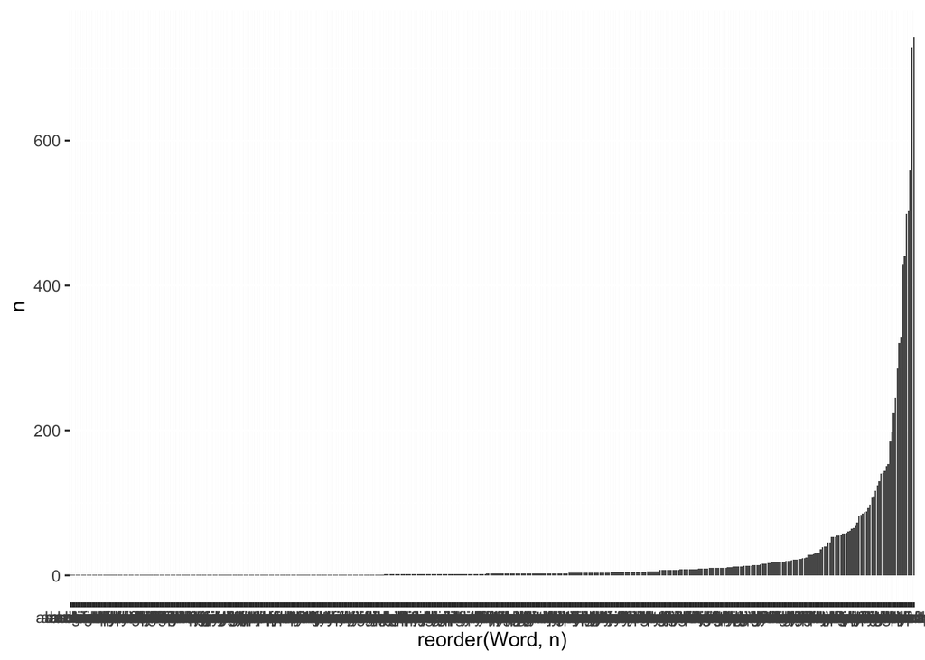

```r
adj_counts %>% ggplot(aes(x = reorder(Word, n), y = n)) +
  geom_col()
```

Get rid of all words that do not appear at least five times: (arbitrary, seems sensible as we wouldn’t want to say anything definite about the semantics of words that we have less than ive instances for, but may want to reconsider this)

```r
frequent_adjs <- filter(adj_counts, n >= 5)
```

Visualize this:

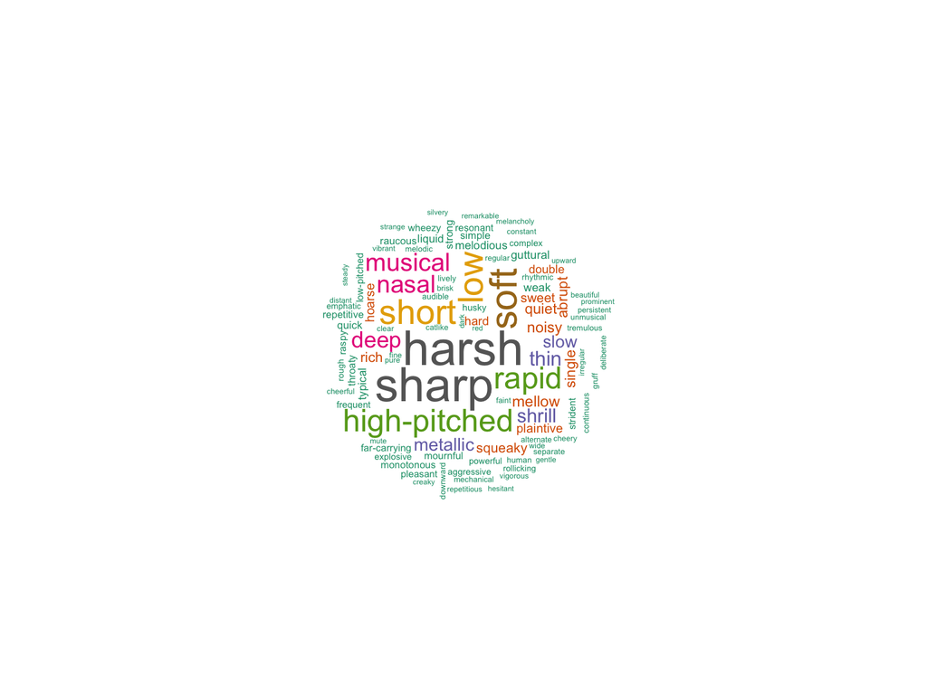

```r
wordcloud(word = frequent_adjs$Word, freq = frequent_adjs$n, min.freq = 12,
          max.words = 120, random.order = FALSE, rot.per = 0.25,
          colors = brewer.pal(8, 'Dark2'),
          scale = c(2.5, 0.35))
```

## Touch-based language

Load in Lynott & Connell (2009):

```r
lyn <- read_csv('../data/other_data/lynott_norms.csv') %>% rename(Word = Property)
```

Merge with tokens:

```r
lyn_tokens <- left_join(all_tokens, lyn)
```

Check counts of dominant modality:

```r
lyn_tokens %>% count(DominantModality) %>%
  filter(!is.na(DominantModality)) %>%
  mutate(prop = n / sum(n),
         prop = round(prop, 2))
```

```
## # A tibble: 4 x 3
##   DominantModality     n  prop
##   <chr>            <int> <dbl>
## 1 Auditory          3247 0.47
## 2 Gustatory          121 0.02
## 3 Haptic            1555 0.22
## 4 Visual            2012 0.290
```

This is interesting. VERY few taste metaphors. Much more touch. A lot of the visuals are going to be dimension words such as “deep” which one may to re-think. Presence of auditory language is expected.

Let’s look at how many of the words from the different senses are used in the corpus, using Lynott & Connell (2009) as a baseline?

```r
lyn <- mutate(lyn, UsedYesNo = ifelse(Word %in% all_tokens$Word,
                                      "yes", "no"))
```

Check how many per sensory modalitY:

```r
table(lyn$DominantModality, lyn$UsedYesNo)
```

```
##
##              no yes
##   Auditory   53  15
##   Gustatory  51   3
##   Haptic     52  18
##   Olfactory  26   0
##   Visual    148  57
```

0 of the smell words are used. Only 3 of the taste words! (mostly sweet probably)

Get the row-wise percentages:

```r
round(prop.table(table(lyn$DominantModality, lyn$UsedYesNo), 1), 2)
```

```
##
##               no  yes
##   Auditory  0.78 0.22
##   Gustatory 0.94 0.06
##   Haptic    0.74 0.26
##   Olfactory 1.00 0.00
##   Visual    0.72 0.28
```

What’s interesting is that while a lot of the auditory words are very frequent, in terms of how many of the words from the lexicon are used, touch and sound are quite similar!

The fact that smell is not used at all fits Williams (1976) over Shen and overs; smell really is a bad source domain.

## Check token counts per sensory modality:

Add 0 for 0 smell words:

```r
all_adjs <- left_join(all_adjs, lyn)
with(all_adjs, c(table(DominantModality), 0))
```

```
##  Auditory Gustatory    Haptic    Visual
##      1690       121      1443      1804         0
```

```r
with(all_adjs, chisq.test(c(table(DominantModality), 0)))
```

```
##
##  Chi-squared test for given probabilities
##
## data:  c(table(DominantModality), 0)
## X-squared = 3055.3, df = 4, p-value < 2.2e-16
```

```r
# Standardized residuals:

with(all_adjs, chisq.test(c(table(DominantModality), 0))$stdres)
```

```
##  Auditory Gustatory    Haptic    Visual
##  23.84715 -31.30641  15.16459  27.85448 -35.55981
```

Exclusivity:

```r
t.test(all_adjs$ModalityExclusivity[complete.cases(all_adjs$ModalityExclusivity)],
       lyn$ModalityExclusivity, var.equal = TRUE)
```

```
##
##  Two Sample t-test
##
## data:  all_adjs$ModalityExclusivity[complete.cases(all_adjs$ModalityExclusivity)] and lyn$ModalityExclusivity
## t = -7.1828, df = 5479, p-value = 7.74e-13
## alternative hypothesis: true difference in means is not equal to 0
## 95 percent confidence interval:
##  -0.08039512 -0.04592015
## sample estimates:
## mean of x mean of y
## 0.3978493 0.4610069
```

```r
cohen.d(all_adjs$ModalityExclusivity[complete.cases(all_adjs$ModalityExclusivity)],
        lyn$ModalityExclusivity)
```

```
##
## Cohen's d
##
## d estimate: -0.3635518 (small)
## 95 percent confidence interval:
##      lower      upper
## -0.4630085 -0.2640952
```

## Extract the onomatopoeias:

All onomatopoeias:

```r
all_onoms <- str_extract_all(birds$Voice, '\\".+?\\"')
birds$AllOnoms <- character(nrow(birds))
for (i in seq_along(all_onoms)) {
   this_onoms <- str_replace_all(all_onoms[[i]], '\"', '')
   if (length(this_onoms) != 0) {
     birds[i, ]$AllOnoms <- str_c(this_onoms, collapse = '; ')
   }
}
```

Replace "" with NA for easier counting:

```r
birds <- mutate(birds,
                AllOnoms = ifelse(AllOnoms == '', NA, AllOnoms))
```

Count:

```r
nrow(birds)
```

```
## [1] 6046
```

```r
# No onomatopoeia:

nrow(filter(birds, is.na(AllOnoms)))
```

```
## [1] 1958
```

```r
# Percentage:

nrow(filter(birds, is.na(AllOnoms))) / nrow(birds)
```

```
## [1] 0.3238505
```

```r
# With  onomatopoeia:

nrow(filter(birds, !is.na(AllOnoms)))
```

```
## [1] 4088
```

```r
# Percentage:

nrow(filter(birds, !is.na(AllOnoms))) / nrow(birds)
```

```
## [1] 0.6761495
```

Compare some of the onomatopeias across different species.

```r
# House sparrow:

filter(birds, EnglishCommon == 'House Sparrow') %>% pull(AllOnoms)
```

```
##  [1] " cheep ;  cheep ;  chirrup "
##  [2] NA
##  [3] NA
##  [4] "chirrup"
##  [5] NA
##  [6] "cheep; chissis"
##  [7] NA
##  [8] "chirrup; chissik; kur-r-r-rit; treeee"
##  [9] "cheelip"
## [10] NA
## [11] NA
## [12] NA
## [13] NA
```

```r
# Common tern:

filter(birds, EnglishCommon == 'Common Tern') %>% pull(AllOnoms)
```

```
##  [1] " kee-ar ;  kip "
##  [2] "kee-urr"
##  [3] "kreeear"
##  [4] "kirri-kirri-kirri; kee-aarh"
##  [5] NA
##  [6] "kree-err; kirri-kirri"
##  [7] "keee-yaah"
##  [8] "kik-kik-kik; kirrik-kirrik; krek, krek; kwarr"
##  [9] "kip; kee-a-r-r-r"
## [10] "keee-yarrr"
## [11] "kee-yaaarr"
## [12] "kip; keee-arrrr"
## [13] "ki-ork; kik-kik-kik"
```

```r
# Wood sandpiper:

filter(birds, EnglishCommon == 'Wood Sandpiper') %>% pull(AllOnoms)
```

```
##  [1] "chip-ip-ip"
##  [2] "chiff-iff-iff"
##  [3] "chiff-if-if"
##  [4] "tlea-tleea-tleea; chiff-iff-iff"
##  [5] "chiff-iff-iff"
##  [6] "chi-chi-chip; chi-chi-chi-chip; chip"
##  [7] NA
##  [8] "chiff-if-if"
##  [9] NA
## [10] "tiff-iff-iff"
```

```r
# Willow warbler:

filter(birds, EnglishCommon == 'Willow Warbler') %>% pull(AllOnoms)
```

```
##  [1] "fooeed"
##  [2] "hueet"
##  [3] "hoo-eet"
##  [4] NA
##  [5] "hooeet; sooeet-sooeetoo"
##  [6] "hoo-ee"
##  [7] "hoo-eet"
##  [8] "hoo-eet"
##  [9] "huweet"
## [10] "si-si-sisi-swee-swee-su-su-sweetsweet-sweetu"
```

```r
# Whimbrel:

filter(birds, EnglishCommon == 'Whimbrel') %>% pull(AllOnoms)
```

```
##  [1] " cur-lee ;  wee-ee.  "
##  [2] NA
##  [3] NA
##  [4] "pee-pee-pee-pee-pee-pee-pee"
##  [5] NA
##  [6] "pe,pe,pe,pe,pe,pe,pe; seven whistler"
##  [7] "ti-ti-ti-; ti-tititititititi…; keer-keer-keer; ke-ee-r"
##  [8] NA
##  [9] "titti-titti-titti-titti"
## [10] "ti-ti-i-ti-ti-ti-ti"
## [11] "tee-tee-tee"
```

```r
# Yellow Wagtail:

filter(birds, EnglishCommon == 'Yellow Wagtail') %>% pull(AllOnoms)
```

```
##  [1] "tseep"             "tsree-ee"          "tseep"
##  [4] "tsweep"            "tsweep"            "psweep"
##  [7] "chzeeip; tsweeip"  "twseep"            "tsweep; tsree-ree"
## [10] NA
```

Get all unique syllables:

```r
all_units <- birds %>% unnest_tokens(Unit, AllOnoms) %>% pull(Unit)
all_units <- tibble(Unit = all_units) %>% filter(!is.na(Unit))
```

Make a count of this:

```r
unit_count <- all_units %>% count(Unit, sort = TRUE)
unit_count
```

```
## # A tibble: 4,198 x 2
##    Unit      n
##    <chr> <int>
##  1 whit    208
##  2 chip    207
##  3 a       171
##  4 r       151
##  5 see     143
##  6 coo     140
##  7 kee     140
##  8 chi     121
##  9 pee     120
## 10 wee     116
## # … with 4,188 more rows
```

What are the type and token counts of syllables?

```r
nrow(unit_count) # types
```

```
## [1] 4198
```

```r
sum(unit_count$n) # tokens
```

```
## [1] 16054
```

Make a word cloud of this:

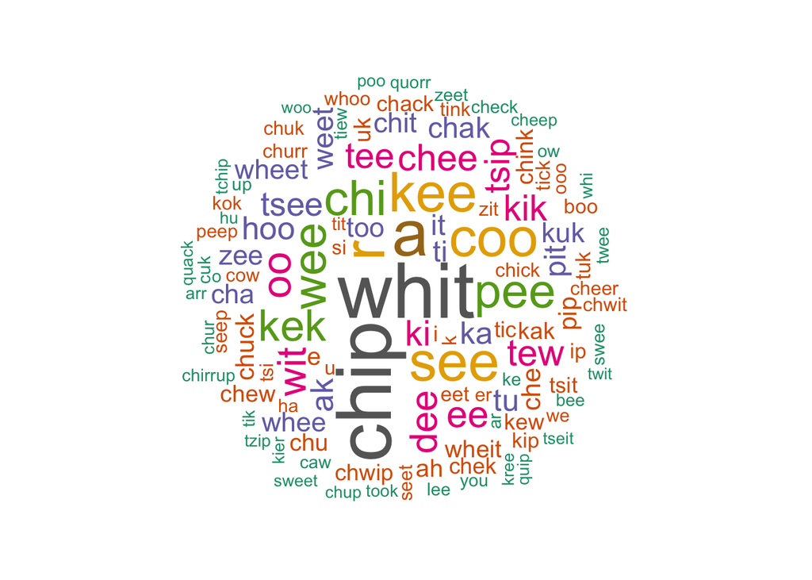

```r
wordcloud(word = unit_count$Unit, freq = unit_count$n, min.freq = 10,
          max.words = 120, random.order = FALSE, rot.per = 0.25,
          colors = brewer.pal(8, 'Dark2'))
```

## Try some LSA

Using https://quanteda.io/articles/pkgdown/examples/lsa.html here to guide me.

First, let’s get the texts that don’t have stop words, and group texts by species (across field guides). We will also make sure that we only take words that occur at least 5 times in the corpus (arbitrary, will have to revisit):

```r
# Get words that occur at least three times:

word_counts <- all_tokens %>% count(Word) %>% filter(n >= 5)
token_min3 <- all_tokens %>% filter(Word %in% word_counts$Word)

# Make this back into a text:

new_texts <- token_min3 %>% group_by(LatinSpecies) %>%
  summarize(text = str_c(Word, collapse = ' ')) %>% ungroup()

# Check:

new_texts
```

Probably need to clean this for non-distinctive words… also no source-terms / bird comparisons etc.

The texts need to have at least 3 words (arbitrary, need to re-asses later).

```r
new_texts <- mutate(new_texts, count = str_count(text, pattern = '[a-z]+'))

# Check:

new_texts %>% count(count)

# Exclude:

new_texts <- filter(new_texts, count >= 3)

# Double-check:

new_texts
```

First, take the voice descriptions and create a term-document matrix (which is a term-bird matrix here…):

```r
txt <- new_texts$text
mydfm <- dfm(txt)

# Check:

mydfm
```

Create LSA model:

```r
mylsa <- textmodel_lsa(mydfm)
```

Get the features (= words?):

```r
features <- mylsa$features
all_words <- row.names(features)
```

Check the LSA fun package:

```r
Cosine('thin', 'high-pitched', tvectors = mylsa$features)
```

Check neighbors:

```r
neighbors('thin', n = 20, tvectors = mylsa$features)
```

O.k., so there’s lots of irrelevant words in there that need to be excluded… probably want it to be focused on adjectives only?

```r
neighbors('soft', n = 20, tvectors = mylsa$features)
```

```r
neighbors('harsh', n = 20, tvectors = mylsa$features)
```

Plot some words:

```r
words <- c('loud', 'quiet', 'soft', 'high-pitched', 'thin', 'harsh', 'rough',
           'dull', 'mellow', 'plaintive', 'abrupt', 'sharp', 'chatter',
           'twitter', 'whistle', 'shrill', 'squeak', 'squeal', 'squeaky',
           'screech', 'metallic', 'musical', 'melodious',
           'clear', 'pleasant', 'noisy', 'rich', 'nasal', 'deep',
           'low-pitched', 'low', 'high', 'piping', 'faint', 'rhythmic')

plot_wordlist(words, method = "MDS", dims = 2, tvectors = mylsa$features)
```

If I was to run a cluster analysis on this:

```r
x <- plot_wordlist(words, method = "MDS", dims = 2, tvectors = mylsa$features)
plot(hclust(dist(x)))
```

This could produce interesting results, with more thought!

Perform clustering on the raw LSA features (not sure if this makes sense; also not decided yet that this is the best clustering algorithm):

```r
gauss <- Mclust(features)
```

Add cluster classifications to word list:

```r
myclusts <- tibble(Word = all_words, Cluster = gauss$classification,
                   Uncertainty = gauss$uncertainty)

# Sort according to cluster and by uncertainty:

myclusts <- arrange(myclusts, Cluster, Uncertainty)
```

Check:

```r
# First cluster:

filter(myclusts, Cluster == 1)

# Second:

filter(myclusts, Cluster == 2)

# Third:

filter(myclusts, Cluster == 3)

# Fourth:

filter(myclusts, Cluster == 4)

# Fifth:

filter(myclusts, Cluster == 5)

# Sixth:

filter(myclusts, Cluster == 6)

# Seven:

filter(myclusts, Cluster == 7)

# Eight:

filter(myclusts, Cluster == 8)
```

## LSA on adjectives only:

Using https://quanteda.io/articles/pkgdown/examples/lsa.html here to guide me.

Merge the adjectives together into text by species for LSA:

```r
# Take only adjs with >5 tokens:

# all_adjs <- filter(all_adjs, Word %in% frequent_adjs$Word)

# Merge:

adjs_by_species <- all_adjs %>% group_by(LatinSpecies) %>%
  summarize(text = str_c(Word, collapse = ' ')) %>% ungroup()

# Check:

adjs_by_species
```

The texts need to have at least 3 words (arbitrary, need to re-asses later).

```r
adjs_by_species <- mutate(adjs_by_species,
                          count = str_count(text, pattern = '[a-z]+'))

# Check:

adjs_by_species %>% count(count)

# Exclude:

adjs_by_species <- filter(adjs_by_species, count >= 3)

# Double-check:

adjs_by_species
```

First, take the voice descriptions and create a term-document matrix (which is a term-bird matrix here…):

```r
txt <- adjs_by_species$text
mydfm <- dfm(txt)

# Check:

mydfm
```

Create LSA model:

```r
mylsa <- textmodel_lsa(mydfm)
```

Get the features (= words?):

```r
features <- mylsa$features
all_words <- row.names(features)
```

Check the LSA fun package:

```r
Cosine('thin', 'high-pitched', tvectors = mylsa$features)
```

Check neighbors:

```r
neighbors('thin', n = 20, tvectors = mylsa$features)
```

```r
neighbors('soft', n = 20, tvectors = mylsa$features)
```

```r
neighbors('harsh', n = 20, tvectors = mylsa$features)
```

Plot some words:

```r
words <- c('deep', 'full', 'mellow', 'nasal', 'piercing',
           'raspy', 'shrill', 'ringing', 'sweet',
           'weak', 'clear', 'dull', 'hard', 'abrupt',
           'metallic', 'penetrating', 'rough',
           'thin', 'harsh',
           'smooth', 'strident',
           'loud', 'quiet', 'high-pitched',
           'low-pitched', 'high', 'low',
           'soft', 'sharp', 'strong', 'weak', 'feeble',
           'creaky', 'chirpy', 'quiet', 'bright',
           'delicate', 'elegant', 'melodious',
           'musical', 'unmelodious', 'silvery',
           'gentle', 'exuberant', 'angry',
           'scolding', 'excited', 'lyrical',
           'catlike', 'raucous',
           'breezy', 'whiny', 'nasal',
           'wheezy', 'cacophonous',
           'squeaky', 'wooden',
           'strident', 'guttural',
           'throaty', 'ventriloquial')

plot_wordlist(words, method = "MDS", dims = 3, tvectors = mylsa$features)
```

If I was to run a cluster analysis on this:

```r
x <- plot_wordlist(words, method = "MDS", dims = 2, tvectors = mylsa$features)
plot(hclust(dist(x)))
```

This could produce interesting results, with more thought!

Perform clustering on the raw LSA features (not sure if this makes sense; also not decided yet that this is the best clustering algorithm):

```r
gauss <- Mclust(features)
```

Add cluster classifications to word list:

```r
myclusts <- tibble(Word = all_words, Cluster = gauss$classification,
                   Uncertainty = gauss$uncertainty)

# Sort according to cluster and by uncertainty:

myclusts <- arrange(myclusts, Cluster, Uncertainty)
```

Check:

```r
# First cluster:

filter(myclusts, Cluster == 1)

# Second:

filter(myclusts, Cluster == 2)

# Third:

filter(myclusts, Cluster == 3)

# Fourth:

filter(myclusts, Cluster == 4)

# Fifth:

filter(myclusts, Cluster == 5)
```